# Estimating extinction time from the fossil record accounting for measurement error

David Warton

2023-09-28

## Problem statement

Often we wish to estimate the time of extirpation of a species using the fossil record – we have a sequence of estimated dates for the species, measured with error (whose magnitude is assumed to be known). For example, say we have the following data

```r
x=c(14729, 14903, 14743, 14738, 14739, 14741, 14732, 14720, 14657, 14638, 14635, 14631, 14642, 14613, 14577, 14544, 14539, 14545, 14541, 14541, 14507, 14490, 14496, 14440, 14389, 14389, 14413, 14361, 14391, 14373, 14323, 14278, 14306, 14301, 14229, 14101, 14068, 14035, 14057, 14018, 13999, 13951, 13939, 13896, 13835, 13819, 13660, 13485, 13482, 12714, 12514, 12227, 12202, 12122, 12124)
sds=c(333, 176, 305, 301, 282, 278, 264, 261, 286, 309, 311, 295, 245, 256, 293, 252, 259, 302, 290, 289, 282, 240, 299, 279, 224, 230, 287, 216, 273, 284, 299, 251, 293, 301, 392, 268, 253, 244, 128, 161, 203, 175, 115, 158, 194, 207, 85, 98, 78, 55, 115, 179, 186, 243, 252)
```

There are two main sources of uncertainty to account for:

1. *Sampling error*, that is, the last time the species was seen (12122 years ago) is not necessarily the last time it was there.
2. *Measurement error*, because fossil ages were measured with uncertainty (whose standard deviation is assumed to be known in the below).

Currently, methods in the literature account for one or other of these quantities, but typically not both. Classical estimators (Strauss, McInerney’s, *etc*) account for sampling error only, GRIWM constructs confidence intervals which account for measurement error but not sampling error.

The `est_cutt` function in the `reginv` package accounts for both, and produces nearly unbiased estimates of extinction time and confidence intervals that are close to exact.

## Model - the CUTT distribution

I have developed a new technique for modelling fossil ages using a Compound Uniform – Truncated T (CUTT) distribution. Using this distribution assumes

- That, for a fossil of a given age, measurement error estimating its age follows a distribution that is Student’s T multiplied by the provided standard deviation, truncated such that observed age is less than K
- That fossil dates are uniformly distributed over the interval of allowable dates

A truncated normal distribution could also be used (and is a special case of the T, where degrees of freedom is infinite) but I have noticed that measurement error seems to be long-tailed relative to the normal so the T tends to provide a better fit to data.

For example:

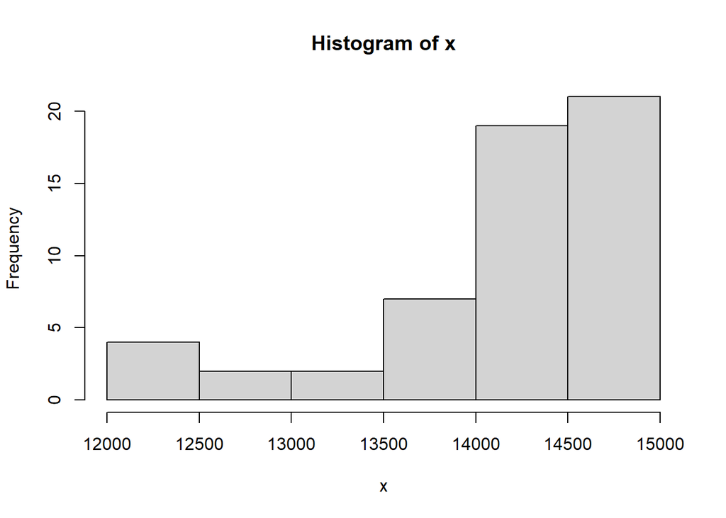

```r
hist(x)
```

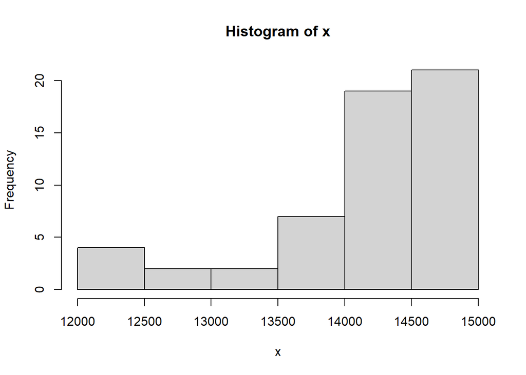

```r
# if required, devtools::install_github("dwarton/reginv")
library(reginv)
hist(x)
```

```r
ft=est_cutt(x,sds,K=15000) # takes maybe a minute to run
print(ft$theta,ft$df)
```

```
##    lo point    hi
## 11952 12286 12579
```